# Predictive Model For Determining Fitness Exercise Correctness

## Abstract

In this assignment, a predictive model was built to determine whether a particular form of exercise (barbell lifting) is performed correctly, using accelerometer data. The data set used is originally from [1].

## Data

The data can be downloaded from the following link using the following R code (download.file(“http://d396qusza40orc.cloudfront.net/predmachlearn/pml-training.csv”,destfile =“pml-training.csv”) ).

The data is in standard CSV format and can be loaded into R from the working directory using the following code:

```r
pml.training <- read.csv("pml-training.csv")
pml.testing <- read.csv("pml-testing.csv")
```

## Exploratory Analysis

The following codes show the dimension and the type and names of the variables in our data set

```r
dim(pml.training)
```

```
## [1] 19622   160
```

```r
str(pml.training)
```

```
## 'data.frame':    19622 obs. of  160 variables:
##  $ X                       : int  1 2 3 4 5 6 7 8 9 10 ...
##  $ user_name               : Factor w/ 6 levels "adelmo","carlitos",..: 2 2 2 2 2 2 2 2 2 2 ...
##  $ raw_timestamp_part_1    : int  1323084231 1323084231 1323084231 1323084232 1323084232 1323084232 1323084232 1323084232 1323084232 1323084232 ...
##  $ raw_timestamp_part_2    : int  788290 808298 820366 120339 196328 304277 368296 440390 484323 484434 ...
##  $ cvtd_timestamp          : Factor w/ 20 levels "02/12/2011 13:32",..: 9 9 9 9 9 9 9 9 9 9 ...
##  $ new_window              : Factor w/ 2 levels "no","yes": 1 1 1 1 1 1 1 1 1 1 ...
##  $ num_window              : int  11 11 11 12 12 12 12 12 12 12 ...
##  $ roll_belt               : num  1.41 1.41 1.42 1.48 1.48 1.45 1.42 1.42 1.43 1.45 ...
##  $ pitch_belt              : num  8.07 8.07 8.07 8.05 8.07 8.06 8.09 8.13 8.16 8.17 ...
##  $ yaw_belt                : num  -94.4 -94.4 -94.4 -94.4 -94.4 -94.4 -94.4 -94.4 -94.4 -94.4 ...
##  $ total_accel_belt        : int  3 3 3 3 3 3 3 3 3 3 ...
##  $ kurtosis_roll_belt      : Factor w/ 397 levels "","-0.016850",..: 1 1 1 1 1 1 1 1 1 1 ...
##  $ kurtosis_picth_belt     : Factor w/ 317 levels "","-0.021887",..: 1 1 1 1 1 1 1 1 1 1 ...
##  $ kurtosis_yaw_belt       : Factor w/ 2 levels "","#DIV/0!": 1 1 1 1 1 1 1 1 1 1 ...
```

[output cut: 86 more lines]

```r
dim(pml.testing)
```

```
## [1]  20 160
```

Choosing between discarding most of the observations but using more predictors and discarding some predictors to keep most of the observations is easy: more observations are always a good thing, while additional variables may or may not be helpful.

Additionally, it’s worth noting that some of the variables in the data set do not come from accelerometer measurements and record experimental setup or participants’ data. Treating those as potential confounders is a sane thing to do, so in addition to predictors with missing data, I also discarded the following variables: X, user_name, raw_timestamp_part1, raw_timestamp_part2, cvtd_timestamp, new_window and num_window.

```r
include.cols <- c("roll_belt", "pitch_belt", "yaw_belt", "total_accel_belt",
    "gyros_belt_x", "gyros_belt_y", "gyros_belt_z", "accel_belt_x", "accel_belt_y",
    "accel_belt_z", "magnet_belt_x", "magnet_belt_y", "magnet_belt_z", "roll_arm",
    "pitch_arm", "yaw_arm", "total_accel_arm", "gyros_arm_x", "gyros_arm_y",
    "gyros_arm_z", "accel_arm_x", "accel_arm_y", "accel_arm_z", "magnet_arm_x",
    "magnet_arm_y", "magnet_arm_z", "roll_dumbbell", "pitch_dumbbell", "yaw_dumbbell",
    "total_accel_dumbbell", "gyros_dumbbell_x", "gyros_dumbbell_y", "gyros_dumbbell_z",
    "accel_dumbbell_x", "accel_dumbbell_y", "accel_dumbbell_z", "magnet_dumbbell_x",
    "magnet_dumbbell_y", "magnet_dumbbell_z", "roll_forearm", "pitch_forearm",
    "yaw_forearm", "total_accel_forearm", "gyros_forearm_x", "gyros_forearm_y",
    "gyros_forearm_z", "accel_forearm_x", "accel_forearm_y", "accel_forearm_z",
    "magnet_forearm_x", "magnet_forearm_y", "magnet_forearm_z")
proc.pml.testing <- pml.testing[, include.cols]
include.cols <- c(include.cols, "classe")
proc.pml.training <- pml.training[, include.cols]
```

Performing this transformation results in a data set of 19622 observations of 53 variables (one of which is the dependent variable “classe”).

```r
dim(proc.pml.training)
```

```
## [1] 19622    53
```

```r
sum(complete.cases(proc.pml.training))
```

```
## [1] 19622
```

Now that I’ve cleaned up the data set, it would make sense to explore associations in the data.

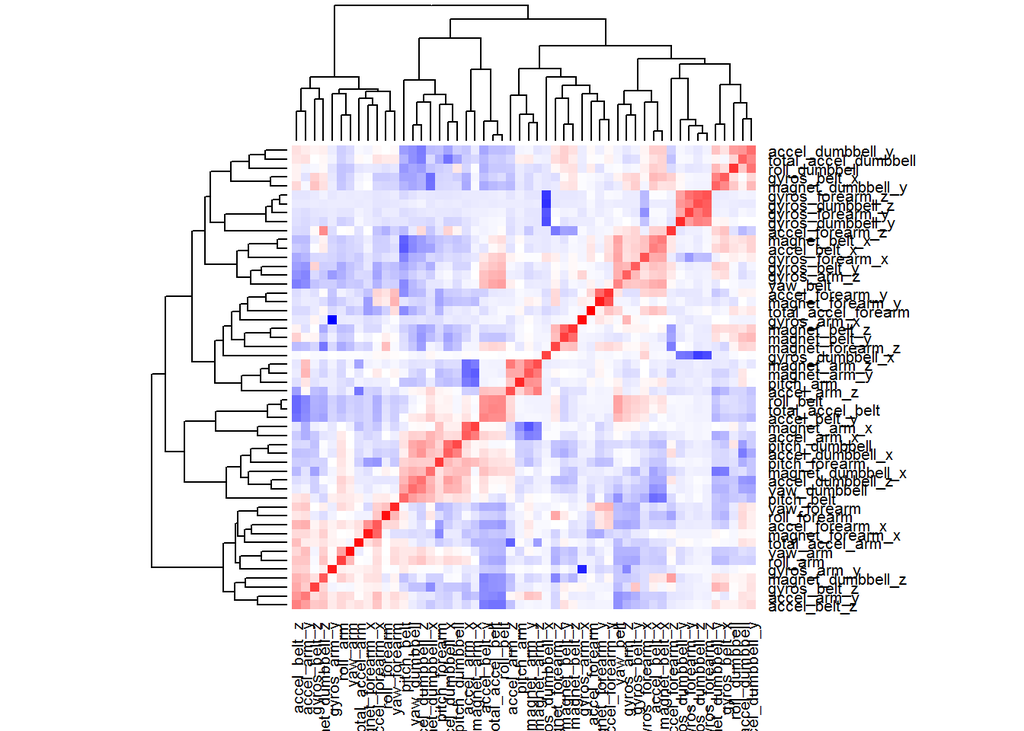

```r
pred.corr <- cor(proc.pml.training[, names(proc.pml.training) != "classe"])
pal <- colorRampPalette(c("blue", "white", "red"))(n = 199)
heatmap(pred.corr, col = pal)
```

As can be seen from the heat map of the correlation matrix, most of predictors do not exhibit high degree of correlation. Nonetheless, there are a few pairs of variables that are highly correlated:

```r
pred.corr[(pred.corr < -0.8 | pred.corr > 0.8) & pred.corr != 1]
```

```
##  [1]  0.8152  0.9809  0.9249 -0.9920 -0.9657 -0.8842  0.8152  0.9809
##  [9]  0.9278 -0.9749 -0.9657  0.8921  0.9249  0.9278 -0.9334 -0.9920
## [17] -0.9749 -0.9334 -0.8842  0.8921 -0.9182 -0.9182  0.8143  0.8143
## [25]  0.8144  0.8144  0.8083  0.8491 -0.9790 -0.9145 -0.9790  0.9330
## [33]  0.8083  0.8491  0.8456 -0.9145  0.9330  0.8456
```

There are nineteen variable pairs the Pearson correlation coefficient for which is above an arbitrary cutoff of 0.8 (in absolute value). To avoid throwing out the baby with the bath water, I chose an even more arbitrary cutoff of 0.98, and found that there are two pairs of variables that lie above this threshold.

```r
which(pred.corr > 0.98 & pred.corr != 1)
```

```
## [1]   4 157
```

```r
pred.corr[which(pred.corr > 0.98 & pred.corr != 1)]
```

```
## [1] 0.9809 0.9809
```

```r
which(pred.corr < -0.9)
```

```
##  [1]   10   60  166  366  426  469  472  477  903  954 1593 1606 1695 2371
```

```r
pred.corr[which(pred.corr < -0.9)]
```

```
##  [1] -0.9920 -0.9657 -0.9749 -0.9657 -0.9334 -0.9920 -0.9749 -0.9334
##  [9] -0.9182 -0.9182 -0.9790 -0.9145 -0.9790 -0.9145
```

Interestingly, the roll_belt predictor participates in both of these pairwise interactions:

```r
pred.corr["roll_belt", "total_accel_belt"]
```

```
## [1] 0.9809
```

```r
pred.corr["roll_belt", "accel_belt_z"]
```

```
## [1] -0.992
```

## Predictive Model

For my initial attempt at building a predictive model I chose the random forest algorithm [2]. Random forests have several nice theoretical properties:

- They deal naturally with non-linearity, and assuming linearity in this case would be imprudent.
- There’s no parameter selection involved. While random forest may overfit a given data set, just as any other machine learning algorithm, it has been shown by Breiman that classifier variance does not grow with the number of trees used (unlike with Adaboosted decision trees, for example). Therefore, it’s always better to use more trees, memory and computational power allowing.
- The algorithm allows for good in-training estimates of variable importance and generalization error [2], which largely eliminates the need for a separate validation stage, though obtaining a proper generalization error estimate on a testing set would still be prudent.
- The algorithm is generally robust to outliers and correlated covariates [2], which seems like a nice property to have when there are known interactions between variables and no data on presence of outliers in the data set.

Given that the problem at hand is a high-dimensional classification problem with number of observations much exceeding the number of predictors, random forest seems like a sound choice.

To make sure that the analysis is reproducible, seed was set .

```r
library(randomForest)
library(caret)
set.seed(111)
```

Let’s train a classifier using all of our independent variables and 200 trees. Th crossvalidation is done internally. The randomForest function has its built in cross validation function.

```r
rf <- randomForest(classe ~ ., data = proc.pml.training, ntree = 200)
rf
```

```
##
## Call:
##  randomForest(formula = classe ~ ., data = proc.pml.training,      ntree = 200)
##                Type of random forest: classification
##                      Number of trees: 200
## No. of variables tried at each split: 7
##
##         OOB estimate of  error rate: 0.27%
## Confusion matrix:
##      A    B    C    D    E class.error
## A 5577    2    0    0    1   0.0005376
## B   10 3782    5    0    0   0.0039505
## C    0    9 3413    0    0   0.0026300
## D    0    0   21 3193    2   0.0071517
## E    0    0    0    3 3604   0.0008317
```

```r
rf$confusion
```

```
##      A    B    C    D    E class.error
## A 5577    2    0    0    1   0.0005376
## B   10 3782    5    0    0   0.0039505
## C    0    9 3413    0    0   0.0026300
## D    0    0   21 3193    2   0.0071517
## E    0    0    0    3 3604   0.0008317
```

The confusion matrix also looks good, indicating that the model fit the training set well. It may also be instructive to look at the variable importance estimates obtained by the classifier training algorithm.

```r
imp <- varImp(rf)
imp$Variable <- row.names(imp)
imp[order(imp$Overall, decreasing = T), ]
```

```
##                      Overall             Variable
## roll_belt            1268.79            roll_belt
## yaw_belt              928.47             yaw_belt
## pitch_forearm         791.44        pitch_forearm
## magnet_dumbbell_z     768.58    magnet_dumbbell_z
## pitch_belt            724.44           pitch_belt
## magnet_dumbbell_y     676.99    magnet_dumbbell_y
## roll_forearm          569.45         roll_forearm
## magnet_dumbbell_x     481.69    magnet_dumbbell_x
## accel_dumbbell_y      411.41     accel_dumbbell_y
## accel_belt_z          408.86         accel_belt_z
## roll_dumbbell         406.71        roll_dumbbell
## magnet_belt_z         393.03        magnet_belt_z
## magnet_belt_y         388.22        magnet_belt_y
## accel_forearm_x       335.67      accel_forearm_x
## gyros_belt_z          328.19         gyros_belt_z
## accel_dumbbell_z      328.05     accel_dumbbell_z
## roll_arm              318.33             roll_arm
## magnet_forearm_z      293.73     magnet_forearm_z
## total_accel_dumbbell  265.95 total_accel_dumbbell
## accel_dumbbell_x      251.75     accel_dumbbell_x
## magnet_belt_x         250.11        magnet_belt_x
## magnet_arm_x          249.24         magnet_arm_x
## yaw_dumbbell          248.55         yaw_dumbbell
## accel_forearm_z       247.83      accel_forearm_z
## accel_arm_x           244.46          accel_arm_x
## gyros_dumbbell_y      239.65     gyros_dumbbell_y
## yaw_arm               238.54              yaw_arm
## magnet_arm_y          221.55         magnet_arm_y
## magnet_forearm_y      221.48     magnet_forearm_y
## magnet_forearm_x      211.40     magnet_forearm_x
## total_accel_belt      205.17     total_accel_belt
## magnet_arm_z          176.62         magnet_arm_z
## yaw_forearm           174.56          yaw_forearm
## pitch_dumbbell        172.89       pitch_dumbbell
## pitch_arm             172.35            pitch_arm
## accel_arm_y           155.96          accel_arm_y
## accel_forearm_y       140.25      accel_forearm_y
## accel_arm_z           140.21          accel_arm_z
## gyros_arm_y           135.21          gyros_arm_y
## gyros_arm_x           131.57          gyros_arm_x
## accel_belt_y          128.92         accel_belt_y
## gyros_forearm_y       124.90      gyros_forearm_y
## gyros_belt_y          118.75         gyros_belt_y
## gyros_dumbbell_x      117.37     gyros_dumbbell_x
## accel_belt_x          115.86         accel_belt_x
## total_accel_forearm   102.81  total_accel_forearm
## total_accel_arm       101.88      total_accel_arm
## gyros_belt_x           91.91         gyros_belt_x
## gyros_forearm_z        84.63      gyros_forearm_z
## gyros_dumbbell_z       80.18     gyros_dumbbell_z
## gyros_forearm_x        73.22      gyros_forearm_x
## gyros_arm_z            55.75          gyros_arm_z
```

Only 11 variables have importance measure more than ten times lower than the most important variable (roll_belt), which seems to indicate the algorithm employed made good use of provided predictors.

## Conclusion

Given that the model obtained using the initial approach appears to be highly successful by all available measures, further exploration of the matter does not seem to be necessary.

## References

1. Ugulino, W.; Cardador, D.; Vega, K.; Velloso, E.; Milidiu, R.; Fuks, H. Wearable Computing: Accelerometers’ Data Classification of Body Postures and Movements. Proceedings of 21st Brazilian Symposium on Artificial Intelligence. Advances in Artificial Intelligence - SBIA 2012. In: Lecture Notes in Computer Science., pp. 52-61. Curitiba, PR: Springer Berlin / Heidelberg, 2012. ISBN 978-3-642-34458-9. DOI: 10.1007/978-3-642-34459-6_6.
2. Breiman, L. (2001). Random forests. Machine learning, 45(1), 5-32.